# Week 3: Random Variables and Distributions

PS 812 - Introduction to Statistical Methods in Political Science

Anton Strezhnev

strezhnev@wisc.edu

University of Wisconsin-Madison

September 22, 2026

## Welcome back!

$$\newcommand{\Var}{\text{Var}}$$

## Week overview

- Last week
  - Conditional probability
  - Independence and conditional independence
  - Bayes’ rule
- This week
  - **Random variables**
  - **Distributions**
  - **Expectations and variances**

## Where we’re going

- This week, we’ll go beyond **events** and illustrate a way of talking about random processes that map on to the **real numbers** $\mathbb{R}$
  - These are what we’ll call **random variables**
- Random variables are defined by their **distributions**
  - We’ll summarize features of these distributions with quantities like the **expectation** and the **variance**
- These will eventually be our empirical **estimands**
  - The share of residents of Wisconsin who turn out in the 2026 midterm election.
  - The share of residents of a given Wisconsin precinct who turn out in the 2026 midterm election **given** that precinct’s 2024 Harris vote share.
- We will use our observed data to provide **estimates** of these quantities
  - Assume our observations came from the distribution of interest…how “close” is our estimate to the truth?
  - How can we talk about this when we **don’t know** the truth!?

## Random variables

- There are clear limitations in using the language of **events** alone in talking about probabilities
- **Example:** Suppose we’re trying to measure **income** using a random **survey**
  - Let $A_{ik}$ be the event that the respondent $i$ has an income of exactly $k$ dollars.
  - How would we represent the probability that a randomly selected respondent has an income between $50,000 and $100,000?

    $$\begin{aligned}
    P\left(\bigcup_{k = 50{,}000}^{100{,}000} A_{ik}\right) &= \sum_{k = 50{,}000}^{100{,}000} P(A_{ik}) \\
    &= P(A_{i,50000}) + P(A_{i,50001}) + \cdots + P(A_{i,99999}) + P(A_{i,100000})
    \end{aligned}$$
- Suppose we measure in **dollars** but want to calculate the probability that the respondent has an income between **£50,000 and £100,000**?
  - Suppose the exchange rate is itself **random**?
- There has to be a better way!

## Random variables

- A **random variable** is a function that maps from the *sample space* $\Omega$ to the *real numbers* $\mathbb{R}$
  - Returning to our income example, we can now say that $X_i$ is a random variable denoting respondent $i$’s income in dollars
  - Now we can write the probability of our earlier event as $P(50{,}000 \le X_i \le 100{,}000)$

[figure not shown]

## Random variables

- We can construct random variables as functions of other random variables!
- Let $R$ be a random variable denoting the USD-GBP (pounds per dollar) exchange rate on a given day.
- Let $Y_i = R \times X_i$
- The probability that the respondent has an income between **£50,000 and £100,000** is just
  $$P (50{,}000 \le Y_i \le 100{,}000)$$
- $Y_i$ is itself another random variable!

## Random variables: Notation

- We typically refer to **random variables** using capital roman letters
  - (e.g. $X$, $Y$, $D$)
  - Sometimes subscripted when we have repetitions across some margin ($i$ for units or $t$ for time)
- We’ll refer to a **realization** of a random variable using lower-case roman letters
  - e.g. $P(X = x)$ refers to the probability that a random variable $X$ takes on a specific value $x$.
- We’ll refer to the **support** of a random variable with a calligraphic capital letter $\mathcal{X}$
  - The **support** of a random variable $X$ is the **set** of all values where $X$ has non-zero probability (or density for continuous r.v.)

## Distribution functions

- Random variables can be defined by their **distribution** function
  - Typically denoted with a capital $F(\cdot)$
  - Sometimes subscripted to specify the particular random variable: $F_X(\cdot)$
- The **cumulative distribution function** (CDF) gives the **probability** that a particular random variable $X$ takes on a value **less than or equal to** $x$

  $$F_X(x) = P(X \le x)$$

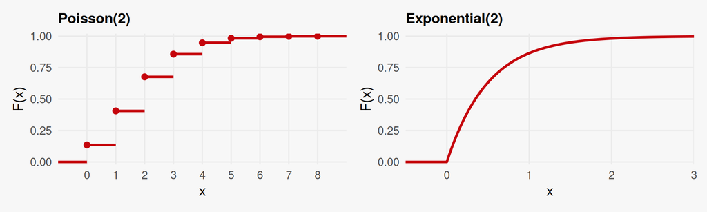

## Distribution functions

- The **range** of a CDF is between $0$ and $1$
  - Its output is a **probability** - probabilities can’t be negative or greater than $1$
- The CDF is **non-decreasing**
  - Remember the conjunction fallacy!
  - Can’t make a probability of an event **smaller** by having it encompass more outcomes!
- Limits
  - As $x \to \infty$, $F_X(x) \to 1$
  - As $x \to -\infty$, $F_X(x) \to 0$

## Distribution functions

- The probability that $X$ lies between two values is just the difference between two evaluations of the CDF.

  $$P(a < X \le b) = F_X(b) - F_X(a)$$
- Why? Consider that $X \le b$ is the union of two disjoint events: $X \le a$ and $a < X \le b$
- The probability of the union of two disjoint events is the sum of their probabilities.

  $$\begin{aligned}
  F_X(b) - F_X(a) &= P(X \le b) - P(X \le a) \\
  &= P([X \le a] \cup [a < X \le b]) - P(X \le a) \\
  &= P([X \le a]) + P([a < X \le b]) - P(X \le a) \\
  &= P(a < X \le b)
  \end{aligned}$$

## Discrete random variables

- We typically discuss two types of random variables: **discrete** and *continuous*
  - Discrete random variables take on a *finite* or *countably infinite* number of values.
  - As a result, we can talk about its **support** as the set where $P(X = x) > 0$
  - In fact, $P(X = x)$ is a coherent idea!
- In the social sciences, essentially everything is *discrete*
  - Our samples are from **large** but **finite** populations (e.g. $262{,}083{,}034$ voting age U.S. residents as of 2023).
  - Our outcomes are discretized (finite number of response options: support/oppose, 5-point Likert).
  - Even something like **income** is technically discrete
- Continuous random variables typically arise as **limits** and/or **approximations**

## Probability mass functions (PMF)

- A **discrete random variable** has a **probability mass function** (PMF)
  - Typically written as lower-case $p(\cdot)$
- The PMF gives the **probability** that a particular random variable $X$ takes on a value **equal to** $x$

  $$p_X(x) = P(X = x)$$

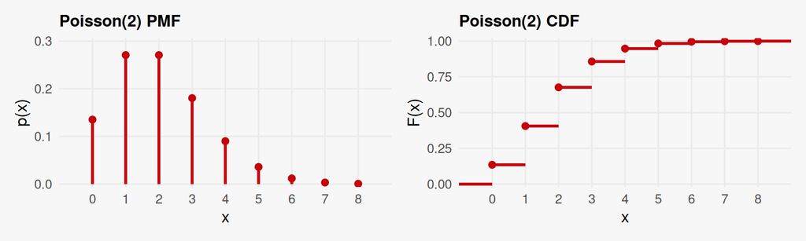

## Probability mass functions (PMF)

- PMFs are **non-negative**: $p_X(x) > 0$ for $x$ in the support and $0$ otherwise
  - Again, PMFs return **probabilities**
- PMFs sum to $1$ over the support of $X$

  $$\sum_{x \in \mathcal{X}} p_X(x) = 1$$
- One can get the **CDF** by summing the PMF over all values *less than or equal to* $x$.

  $$F_X(x) = \sum_{t \in \mathcal{X} : t \le x} p_X(t)$$

## Bernoulli distribution

- The simplest discrete probability distribution is the **Bernoulli** distribution
  - This is the distribution of a **weighted coin flip** with “success” probability $p$

  $$P(X = x) = \begin{cases}
  p & \text{if } x = 1 \\
  1 - p & \text{if } x = 0 \\
  0 & \text{otherwise}
  \end{cases}$$
- We’ll use the $\sim$ syntax to denote that a variable has a particular distribution with particular parameters

  $$X \sim \text{Bernoulli}(p)$$
- Bernoulli random variables often arise from **indicator** functions $\mathbf{1}(\cdot)$ applied to events $A$

  $$\mathbf{1}(A) \sim \text{Bernoulli}(p) \quad p = P(A)$$

## Example: List experiments

- Getting people to be honest on surveys can be difficult for some types of questions.
  - **Social desirability bias** may make some respondents reticent to give truthful answers
- The **2012 Mexico Panel Study** (Greene 2016) wanted to study the prevalence of **vote buying** in the 2012 Mexican presidential election
  - Exchanging a vote for a gift is illegal - survey respondents may not want to admit to a crime!
- **Solution**: A **list experiment** - Respondents are randomly assigned to a “treated” or a “control” group
- Respondents see a list of items and are asked **how many** items on that list they did in recent weeks (not **which ones**)
  1. See a television newscast that mentions a candidate
  2. Attend a campaign event
  3. Talk about politics with other people
  4. **Treated group only:** Exchange your vote for a gift, favor, or access to a service
- Respondents who admit to vote buying are not identifiable (except in one edge case!)
  - But with some assumptions, we can learn the **share** of respondents who experienced vote buying.

## Example: List experiments

- Let $C_i$ be the **number** of items that respondent $i$ would say they did if **assigned to control**
  - $C_i$ is a **random variable** (randomness from both sampling and treatment assignment)
  - It is a discrete random variable that takes on *integers* from $0$ to $3$
- Let $T_i$ be the **number** of items that respondent $i$ would say they did if **assigned to treatment**
  - Here the random variable ranges from integers $0$ to $4$.
- The simplest way to define these distributions is to assign a unique parameter to each possible value

  $$P(C_i = c) = \begin{cases}
  p_0 & \text{if } c = 0 \\
  p_1 & \text{if } c = 1 \\
  p_2 & \text{if } c = 2 \\
  p_3 & \text{if } c = 3 \\
  0 & \text{otherwise}
  \end{cases}
  \qquad p_c \ge 0, \quad \sum_{c=0}^{3} p_c = 1$$

## Example: List experiments

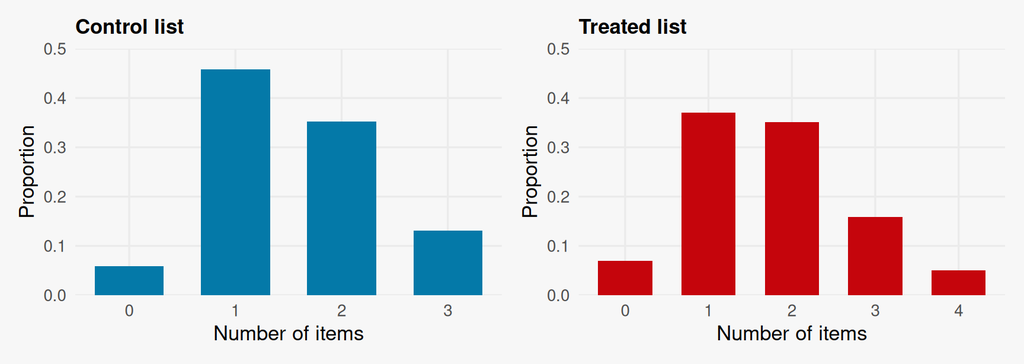

## Example: List experiments

- We want to try to learn about the probability of responding to the sensitive item.
  - Let $Z_i \sim \text{Bernoulli}(\theta)$ be the random variable denoting whether respondent $i$ engaged in **vote buying**
- Now we’ll make some assumptions about how $Z_i$ relates to the other two variables

  $$\underbrace{T_i}_{\text{treated count}} = \underbrace{C_i}_{\text{control count}} + \underbrace{Z_i}_{\text{sensitive item}}$$
- We’ve defined the **data generating process** for the list experiment!
  - What’s the key behavioral assumption hidden here?
  - Respondents’ reaction to the baseline items **doesn’t change** if they’re exposed to the sensitive item.

## Binomial distribution

- We saw how the most flexible way to represent any discrete random variable defined on a **finite** support is to just assign a unique parameter to each unique value.
  - But this can get unwieldy for a lot of statistical tasks - can we be more **parsimonious**?
  - What if we assumed that respondents had a **common** probability $p$ of responding yes to each component of the list and that items were **independent**
- Then we would get the **Binomial** distribution: the distribution of the **sum** of *independent* and *identical* *weighted* coin flips
  - Two parameters: $N$: Number of trials, $p$: Success probability

  $$P(X = x) = \begin{cases}
  \binom{N}{x} p^x (1 - p)^{N - x} & \text{if } x \in \{0, 1, \dots, N\} \\
  0 & \text{otherwise}
  \end{cases}$$

## Expected value

- One very important property of a random variable is its **expectation** $\mathbb{E}[X]$
  - Can think of this as a **summary** of that random variable’s “long-run” behavior.
- For a **discrete** random variable, the expectation is a **weighted average** of that variable’s possible outcomes with the weights given by the **probability** of each outcome

  $$\mathbb{E}[X] = \sum_{x \in \mathcal{X}} x \cdot P(X = x)$$

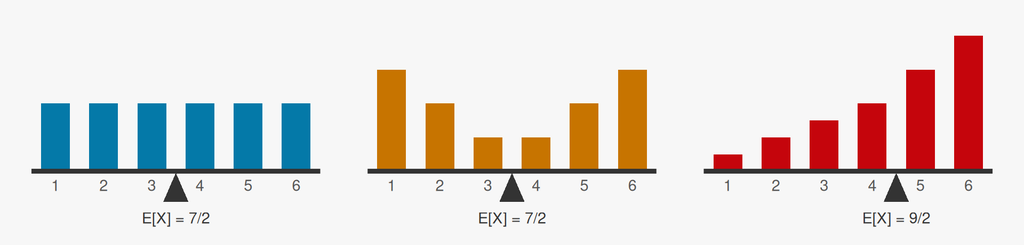

## Expectations of functions

- Suppose I want to know $\mathbb{E}[g(X)]$ where $g()$ is some function.
  - $\mathbb{E}[g(X)] \neq g(\mathbb{E}[X])$ except in a few cases (linear functions)
- An interesting property of the expected value is what is sometimes called the **Law of the Unconscious Statistician** (LOTUS)
- If I just looked at the definition of expectation, I’d think:
  - “What if I just plugged in $g(x)$ instead of $x$ and took the average over the same weights?”
- It turns out that works!

  $$\mathbb{E}[g(X)] = \sum_{x \in \mathcal{X}} g(x) \cdot P(X = x)$$

## Linearity of expectations

- Another essential property of expectations is **linearity**
  - The **expectation of the sum** is the **sum of the expectations**
- Let $X$ and $Y$ be two random variables

  $$\mathbb{E}[X + Y] = \mathbb{E}[X] + \mathbb{E}[Y]$$
- Let $a$ and $b$ be constants: we can pull the constants out of the expectation

  $$\mathbb{E}[aX + bY] = a\mathbb{E}[X] + b\mathbb{E}[Y]$$
- You’ll see this most often with sums over random variables indexed along some dimension

  $$\mathbb{E}\bigg[\sum_{i=1}^n a X_i\bigg] = \sum_{i=1}^n\mathbb{E}[a X_i] = \sum_{i=1}^n a\mathbb{E}[X_i] = a\sum_{i=1}^n \mathbb{E}[X_i]$$

## Expectation of the Bernoulli

- Let $X \sim \text{Bernoulli}(p)$
- There are two possible values, let’s calculate the expectation!

  $$\begin{aligned}
  \mathbb{E}[X] &= \sum_{x \in \{0, 1\}} x \cdot P(X = x) \\
  &= 0 \cdot P(X = 0) + 1 \cdot P(X = 1) \\
  &= 0 \cdot (1 - p) + 1 \cdot p \\
  &= p
  \end{aligned}$$
- The **expected value** of a Bernoulli/indicator random variable is just the **probability** that it takes on a value of $1$
  - This is the **fundamental bridge** between expectations and probability (Blitzstein and Hwang 2019)

## Expectation of the Binomial

- Now let $X \sim \text{Binomial}(N, p)$
- We could write this out and use properties of sums of factorials

  $$\mathbb{E}[X] = \sum_{x=0}^{N} x \cdot \binom{N}{x} p^x (1 - p)^{N - x}$$
- Or we could use **linearity** of expectations - much easier!

## Expectation of the Binomial

- Recall that the **Binomial** is the sum of $N$ independent and identically distributed **Bernoulli** random variables with success probability $p$

  $$X = \sum_{i=1}^N X_i \quad\quad\quad X_i \sim \text{Bernoulli}(p)$$
- Applying linearity of expectations

  $$\mathbb{E}[X] = \mathbb{E}\bigg[\sum_{i=1}^N X_i\bigg] = \sum_{i=1}^N \mathbb{E}[X_i]$$
- Plugging in our expectation of the Bernoulli and summing

  $$\mathbb{E}[X] = Np$$

## Example: List experiment

- Let’s return to our list experiment example. Remember, we have

  $$\underbrace{T_i}_{\text{treated count}} = \underbrace{C_i}_{\text{control count}} + \underbrace{Z_i}_{\text{sensitive item}}$$
- We want to know $P(Z_i = 1) = \theta$ - the share of respondents who participated in **vote buying**
- Taking expectations of both sides and using linearity

  $$\mathbb{E}[T_i] = \mathbb{E}[C_i] + \theta$$
- Solving for $\theta$

  $$\theta = \mathbb{E}[T_i] - \mathbb{E}[C_i]$$

## Preview: Estimation

- In our **sample**, we assume that we observe realizations of these two random variables
  - In the treated group we have $N_{T}$ draws of $T_i$
  - In the control group we have $N_{C}$ draws of $C_i$
- We’ll plug-in an **estimate** of each expectation using its sample analogue: the average

  $$\begin{aligned}
  \hat{\theta} &= \widehat{\mathbb{E}}[T_i] - \widehat{\mathbb{E}}[C_i] \\
  &= \frac{1}{N_T} \sum_{i=1}^{N_T} T_i - \frac{1}{N_C} \sum_{i=1}^{N_C} C_i
  \end{aligned}$$
- Later, we’ll show that under assumptions about **how** we got our sample (i.i.d. random smapling)…
  - …these **sample** averages converge to the population **expected values**
  - “law of large numbers”
- Note that we don’t actually need the assumption that $C_i \sim \text{Binomial}(3, p)$ to estimate $\theta$
  - Just that exposure to the sensitive item doesn’t alter responses to the baseline list

## Preview: Estimation

```r
library(tidyverse)
library(knitr)

# Sample means of the item count in each group
mexico |>
  group_by(Group = if_else(treat == 1, "Treated", "Control")) |>
  summarize(`Mean count` = mean(y), N = n()) |>
  kable(digits = 3)
```

| Group | Mean count | N |
| --- | --- | --- |
| Control | 1.555 | 559 |
| Treated | 1.749 | 561 |

```r
# List experiment estimate of theta vs. share admitting vote buying when asked directly
mexico |>
  summarize(`List experiment` = mean(y[treat == 1]) - mean(y[treat == 0]),
            `Direct question` = mean(direct)) |>
  kable(digits = 3)
```

| List experiment | Direct question |
| --- | --- |
| 0.194 | 0.055 |

## Variance

- Beyond the expectation, there are other summaries that capture other relevant features.
  - We may want to know how **spread out** realizations of the random variable are.
- The **variance** of a random variable $\Var(X)$ is the expected **squared** deviation from $\mathbb{E}[X]$

  $$\Var(X) = \mathbb{E}\bigg[(X - \mathbb{E}[X])^2\bigg]$$
- Expanding the square and applying linearity of expectation

  $$\Var(X) = \mathbb{E}[X^2] - \mathbb{E}[2X\mathbb{E}[X]] + \mathbb{E}[\mathbb{E}[X]^2]$$
- Pulling out the constant $2\mathbb{E}[X]$ and $\mathbb{E}[X]^2$

  $$\begin{aligned}
  \Var(X) &= \mathbb{E}[X^2] - 2\mathbb{E}[X]\mathbb{E}[X] + \mathbb{E}[X]^2 \\
  &= \mathbb{E}[X^2] - \mathbb{E}[X]^2
  \end{aligned}$$

## Properties of variance

- The variance is **non-negative**
  - By **Jensen’s inequality** for a convex function: $\mathbb{E}[X^2] \ge \mathbb{E}[X]^2$
- For a random variable $X$ and a constant $a$

  $$\Var(aX) = a^2\Var(X)$$
- But be careful, the variance of the sum of two random variables $X$ and $Y$ is **not** the sum of the variances except in a special case we’ll talk about next week (independence)

  $$\Var(X + Y) \neq \Var(X) + \Var(Y)$$
- Also, the variance of the **difference** is not the difference in the variances…even for independent random variables, it’s still the sum of the variances ($-1$ gets squared!)
  - We’ll talk about this more next week when we define **covariance**

## Variance of a Bernoulli

- Let’s derive the variance of the Bernoulli. Let $X \sim \text{Bernoulli}(p)$

  $$\begin{aligned}
  \Var(X) &= \mathbb{E}[X^2] - \mathbb{E}[X]^2 \\
  &= \mathbb{E}[X] - \mathbb{E}[X]^2 \\
  &= p - p^2 \\
  &= p(1 - p)
  \end{aligned}$$
- The second line uses the fact that $X$ only takes on the values $0$ and $1$. $0^2 = 0$ and $1^2 = 1$.
- **Intuition**: The uncertainty around a coin-flip is **maximized** when it’s fair!

## Continuous random variables

- Recall the difference between the CDF of a **discrete** versus a **continuous** random variable.

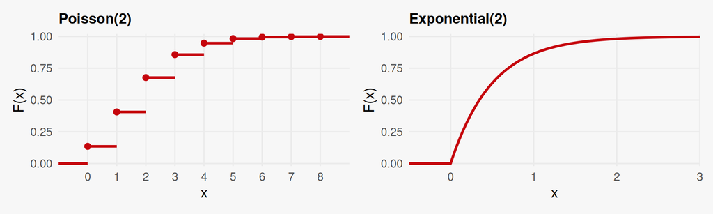

- The **discrete** variable’s CDF has **discontinuities**, the **continuous** variable’s CDF is **continuous** (and **differentiable** almost everywhere)

## Probability density functions (PDFs)

- A **continuous** random variable is a random variable whose CDF is **continuous everywhere** and **differentiable** everywhere except possibly at a finite number of points (Blitzstein and Hwang 2019)
  - The support of a continuous random variable is typically the set of real numbers $\mathbb{R}$ or an interval (or union of intervals) of the reals.
- The challenge with talking about a distribution defined on the **uncountably infinite** reals is that the probability of realizing any particular value $x$ is always **zero**
- Instead of a PMF, continuous random variables have a **probability density function** (PDF) - defined as the **derivative** of the CDF
  - Typical notation is a lowercase $f(\cdot)$

  $$f_X(x) = \frac{d}{dx} F_X(x)$$

## Probability density functions (PDFs)

- It’s not a probability, but it **integrates** to a probability.
  - From the **fundamental theorem of calculus**

  $$F_X(x) = \int_{-\infty}^{x} f_X(t) dt$$
- This is similar to how we **summed** the PMF to get the CDF
- PDFs **integrate** to $1$ (just like how PMFs sum to $1$)

  $$\int_{-\infty}^{\infty} f_X(x)dx = 1$$

## Probability density functions (PDFs)

- And we can integrate the PDF over any *interval* to get the probability of $X$ falling in that interval.

  $$P(a < X \le b) = \int_{a}^{b} f_X(x)dx$$
- Intuitively, this follows from our earlier definition using CDFs

  $$\begin{aligned}
  P(a < X \le b) &= F_X(b) - F_X(a) \\
  &= \int_{-\infty}^{b} f_X(x)dx - \int_{-\infty}^{a} f_X(x)dx \\
  &= \int_{a}^{b} f_X(x)dx
  \end{aligned}$$

## Expectations of continuous random variables

- We defined the expected value for a discrete random variable as a **sum**
  - We’ll do the same for a continuous random variable using an **integral**
- For continuous $X$

  $$\mathbb{E}[X] = \int_{\mathcal{X}} x f(x) dx$$
- More generally, the distinction between discrete and continuous vanishes when we define integrals with respect to the distribution (Lebesgue integration)

  $$\mathbb{E}[X] = \int_{\mathcal{X}} x \, dF_X(x)$$
  - Rather than slicing up the **$x$-axis** into small intervals, we slice up the **probability** and ask how much of it sits at each value of $X$
- But we won’t spend time on that in this class…your Riemann integral intuition (sum of the areas of tinier and tinier rectangles) is enough!

## Normal distribution

- The **normal** (or **Gaussian**) distribution is the most common continuous distribution you’ll encounter
  - It’s the **approximate** distribution of sums and means of independent random variables.
  - $X \sim \mathcal{N}(\mu, \sigma^2)$. Support over all of $\mathbb{R}$.
- The PDF is

  $$f_X(x) = \frac{1}{\sqrt{2\pi\sigma^2}} \exp\left\{-\frac{(x - \mu)^2}{2\sigma^2}\right\}$$
- Two parameters, $\mu$ and $\sigma^2$
  - These parameters happen to be the expectation and variance!
  - $\mu = \mathbb{E}[X]$, $\sigma^2 = \Var(X)$

## Normal distribution

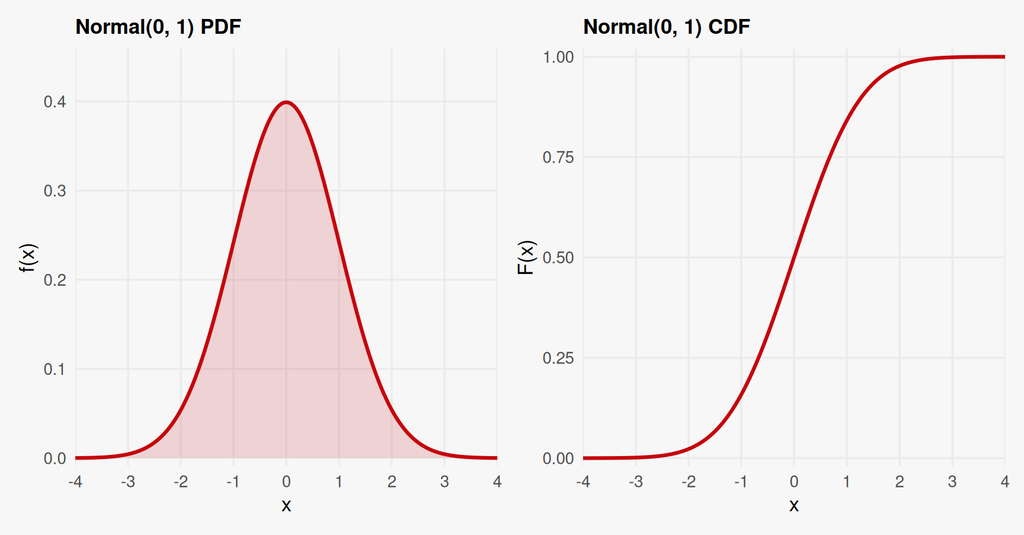

## Normal distribution

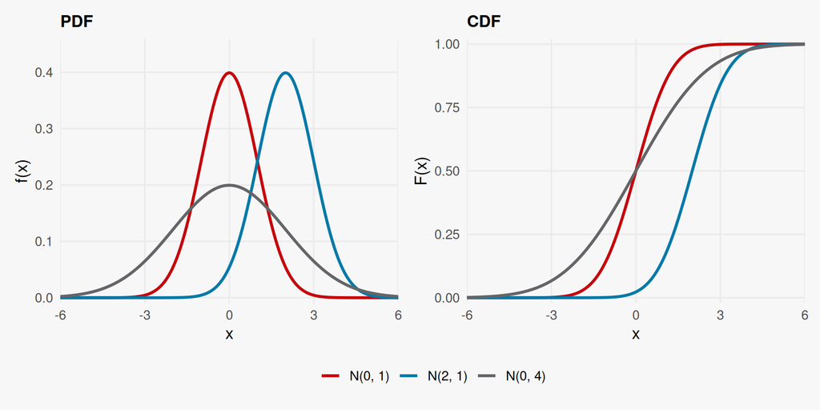

## The standard normal

- $\mathcal{N}(0, 1)$ is referred to as the **standard normal**
  - PDF and CDF typically written as: $\phi(z)$ and $\Phi(z)$

    $$\phi(z) = \frac{1}{\sqrt{2\pi}} e^{-z^2/2}$$
- Any normal can be **standardized**. If $X \sim \mathcal{N}(\mu, \sigma^2)$, then

  $$Z = \frac{X - \mu}{\sigma} \sim \mathcal{N}(0, 1)$$
- $\Phi$ has **no closed form**
  - This is why old stats books had tables of pre-computed quantiles of the normal distribution!
  - And why we’ll rely on our computer + various approximations to evaluate the CDF (`pnorm()`)

## Areas under the normal curve

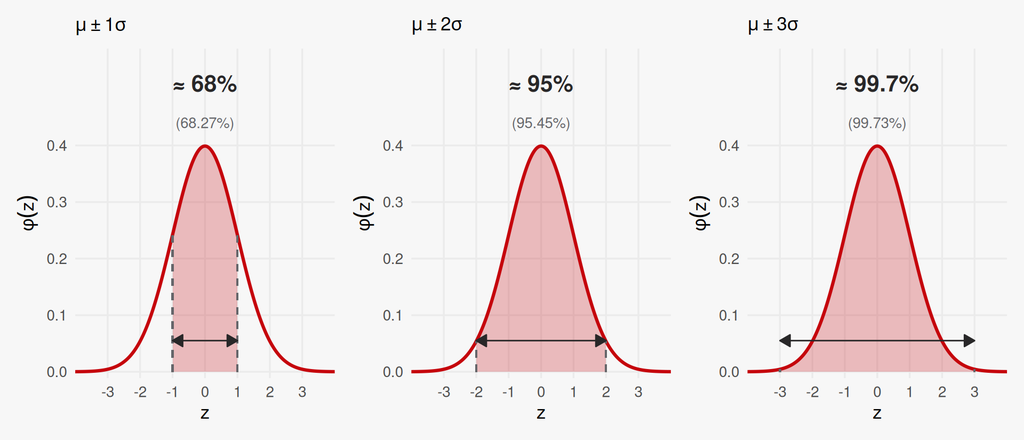

## Next week

- Joint distributions
  - Defining the distribution of $X$ and $Y$ (and $Z$, and…) together!
- Conditional distributions
  - **Slicing** the joint distribution at a particular point
- Conditional expectations and the best linear predictor
  - Law of total expectation
- Covariances and correlations

## References

Blitzstein, Joseph K., and Jessica Hwang. 2019. *Introduction to Probability*. 2nd ed. Chapman; Hall/CRC. https://projects.iq.harvard.edu/stat110/home.

Greene, Kenneth. 2016. *Mexico Panel Study, 2012*. Inter-university Consortium for Political; Social Research (ICPSR). https://doi.org/10.3886/ICPSR35024.v1.